# What influencing everyday clothing choices

## Introduction

In this visual story, I wanted to explore what people around me were wearing in different situations. Instead of looking at clothing as separate items, I used the data to identify small patterns among clothing type, weather, color, and observation time. These plots helped me understand how daily clothing choices may change with the environment and time of day.

## What I observed

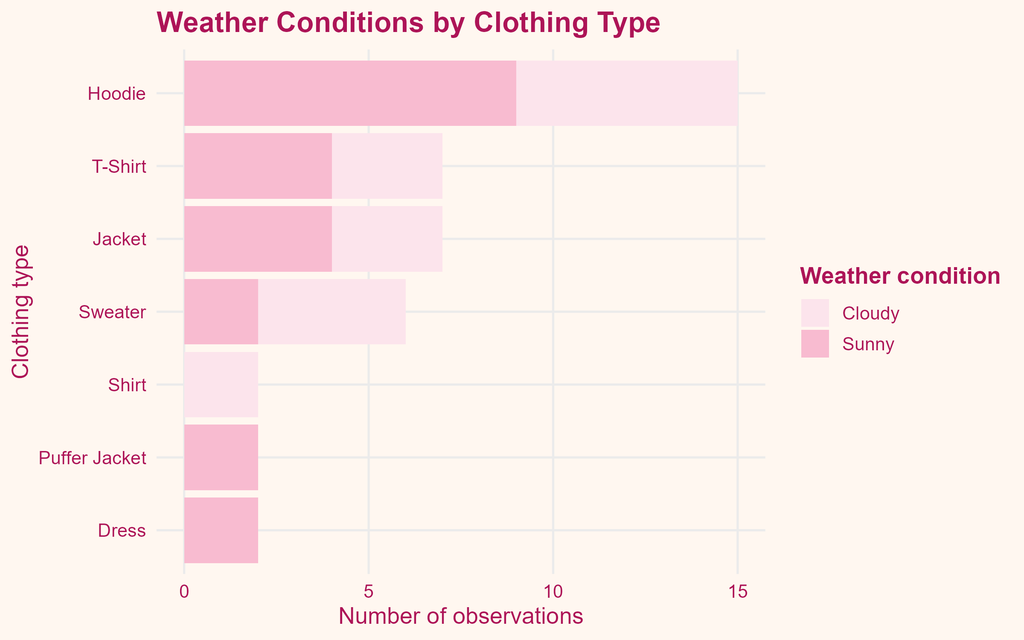

This plot shows the clothing types observed during my two days of data collection. Since the weather was only cloudy and sunny, the weather comparison is limited. Hoodie is the most common clothing type overall, while T-shirts and jackets also appeared several times.

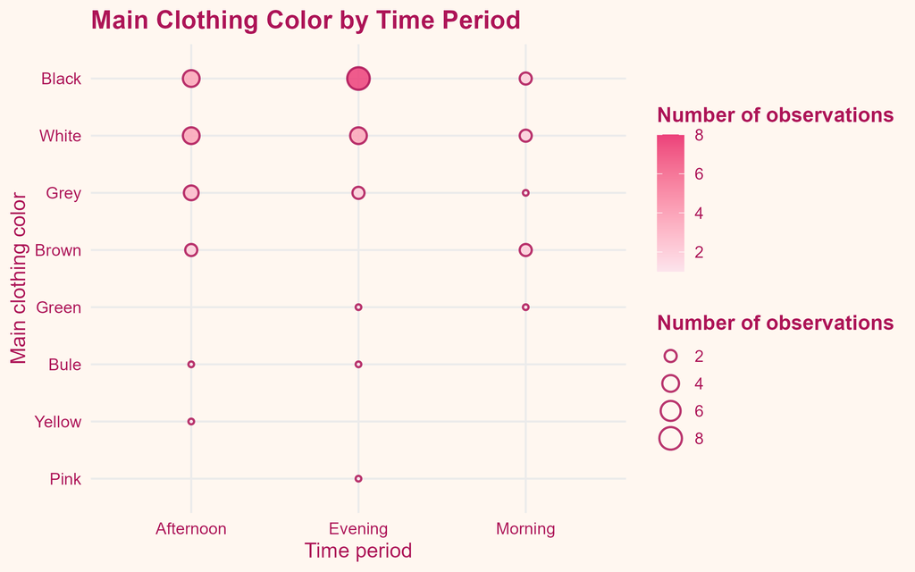

This plot shows the main clothing colors I observed at different times of the day. The clearest pattern is that neutral colors were more common, especially black, white, and grey. Black appeared most often in the evening, while brighter colours appeared much less often.

One possible reason is that my data was affected by my own observation environment. Since I only recorded people around me, the high number of black clothing may simply reflect the people who happened to be nearby during my observations. Therefore, this plot is better understood as a small snapshot of my surroundings, rather than strong evidence that people generally wear more black at certain times.

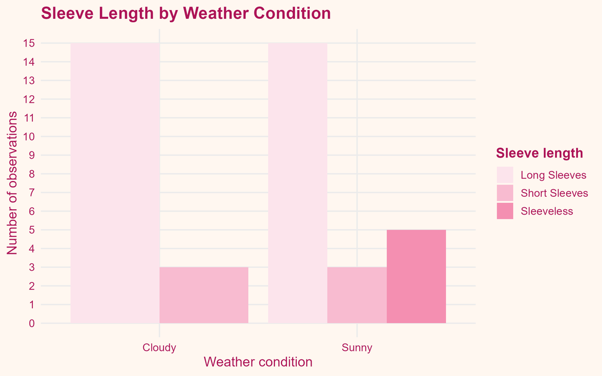

This plot shows sleeve length in cloudy and sunny weather. Long sleeves appeared most often in both weather conditions, while short sleeves and sleeveless clothing were less common.

Although I expected sunny weather to have more short sleeves, the pattern was not very strong. Since the data was collected in autumn, sunny weather did not always mean warm weather. Sleeve length may be related to both weather and temperature, so I cannot say that weather alone explains the clothing choices.

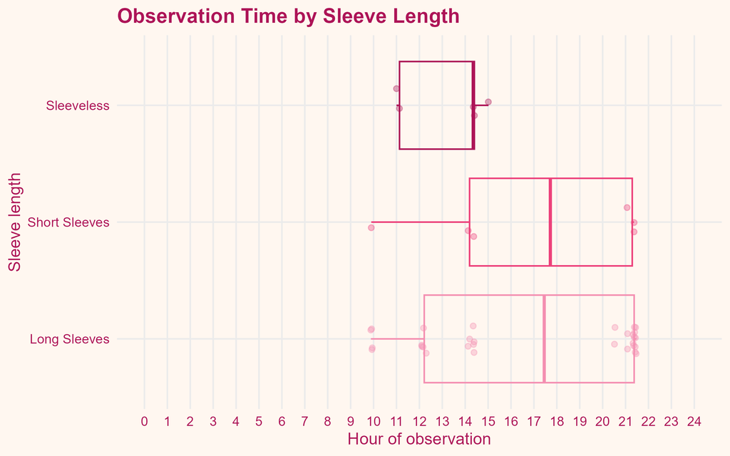

This plot shows when different sleeve lengths were observed during the day. Most of my observations happened from the afternoon to evening, so the data does not represent the whole day equally. Long sleeves and short sleeves both appeared during these times, while sleeveless clothing appeared less often.

This means the pattern may be affected by my observation schedule. Since the data was collected in autumn, the time of day and temperature may also be related to sleeve length. Therefore, this plot is better understood as showing how my observation time shaped the dataset, rather than proving that time alone affects what people wear.

## Conclusion

Looking across the four plots, my data story shows a small picture of everyday clothing around university life. Most of the clothing I observed was casual, neutral-coloured, and practical. Hoodies, long sleeves, and darker colors appeared often, which matched the daily settings where I collected the data.

The most interesting part is that clothing choices were not only connected to weather. Even on sunny days, many people still wore long sleeves. This suggests that season, temperature, comfort, and location may also shape what people wear.

Overall, these visualisations show that my observations were more about everyday student clothing than general fashion trends. If I collected data in a different place, such as a hiking area, shopping mall, or formal event, the story might look very different.